# IE360 Fall

Homework 1

Fatma Nur Dumlupınar

17 11 2020

# 1 Required Packages and Data

```r
library(readxl)
library(ggplot2)
library(dplyr)
library(tidyr)
library(lubridate)
library(RColorBrewer)
library(zoo)

inflation<-read_excel("data/inflation.xlsx")
search_enflasyon<-read.csv("data/search_enflasyon.csv",sep = ",")
search_fiyatartışı<-read.csv("data/search_fiyatartışı.csv",sep = ",")

unemployment<-read_excel("data/monthly_unemployment.xlsx")
search_işilanı<-read.csv("data/search_işilanı.csv",sep = ",")
search_işkur<-read.csv("data/search_işkur.csv",sep = ",")

sales<-readRDS(gzcon(url("https://github.com/pjournal/boun01g-data-mine-r-s/blob/gh-pages/Final%20TakeHome/all_data?raw=true")))
search_araba<-read.csv("data/search_araba.csv",sep = ",")
```

# 2 Data Preparation

```r
#for Inflation Analysis
inflation<-inflation%>%rename(Date=Tarih)%>%
  mutate(Date=as.POSIXct(strptime(Date,"%Y")))%>%
  pivot_longer(.,2:27,names_to="Region",
               values_to="Yearly Inflation Rate")

search_enflasyon<-search_enflasyon%>%rename(Date=Ay,Inflation=enflasyon)%>%
  mutate(Date=as.Date(as.yearmon(Date)))

search_fiyatartışı<-search_fiyatartışı%>%rename(Date=Ay,PriceIncrease=fiyat.artışı)%>%
  mutate(Date=as.Date(as.yearmon(Date)))


#for Unemployment Analysis

unemployment<-unemployment%>%rename(Date=Tarih,UnemploymentRate=`TP TIG07`)%>%
  mutate(Date=as.Date(as.yearmon(Date)))

search_işilanı<-search_işilanı%>%rename(Date=Ay, JobPost=iş.ilanı)%>%
  mutate(Date=as.Date(as.yearmon(Date)))

search_işkur<-search_işkur%>%rename(Date=Ay)%>%
  mutate(Date=as.Date(as.yearmon(Date)))


#for Car Sales Analysis

car_sales<-sales%>%
  group_by(year,month)%>%
  summarise(sales=sum(total_total))

search_araba<-search_araba%>%rename(Date=Ay)%>%
  mutate(Date=as.Date(as.yearmon(Date)))
```

# 3 Data Visualization

## 3.1 Inflation Analysis

### 3.1.1 Yearly Inflation Rate of Regions for each Year

In the inflation data, Turkey is divided into 26 regions which have distinct yearly inflation values for 11 years. The cities in the regions are given below:

**Regions**

1st Region: İstanbul  
2nd Region: Tekirdağ, Edirne, Kırklareli  
3rd Region: Balıkesir, Çanakkale 4th Region: İzmir  
5th Region: Aydın, Denizli, Muğla  
6th Region: Manisa, Afyon, Kütahya, Uşak  
7th Region: Bursa, Eskişehir, Bilecik  
8th Region: Kocaeli, Sakarya, Düzce, Bolu, Yalova  
9th Region: Ankara  
10th Region: Konya, Karaman  
11th Region: Antalya, Isparta, Burdur  
12th Region: Adana, Mersin  
13rd Region: Hatay, Kahramanmaraş, Osmaniye  
14th Region: Kırıkkale, Aksaray, Niğde, Nevşehir, Kırşehir  
15th Region: Kayseri, Sivas, Yozgat  
16th Region: Zonguldak, Karabük, Bartın  
17th Region: Kastamonu, Çankırı, Sinop  
18th Region: Samsun, Tokat, Çorum, Amasya  
19th Region: Trabzon, Ordu, Giresun, Rize, Artvin, Gümüşhane  
20th Region: Erzurum, Erzincan, Bayburt  
21st Region: Ağrı, Kars, Iğdır, Ardahan  
22nd Region: Malatya, Elazığ, Bingöl, Tunceli  
23rd Region: Van, Muş, Bitlis, Hakkari  
24th Region: Gaziantep, Adıyaman, Kilis  
25th Region: Şanlıurfa, Diyarbakır  
26th Region: Mardin, Batman, Şırnak, Siirt

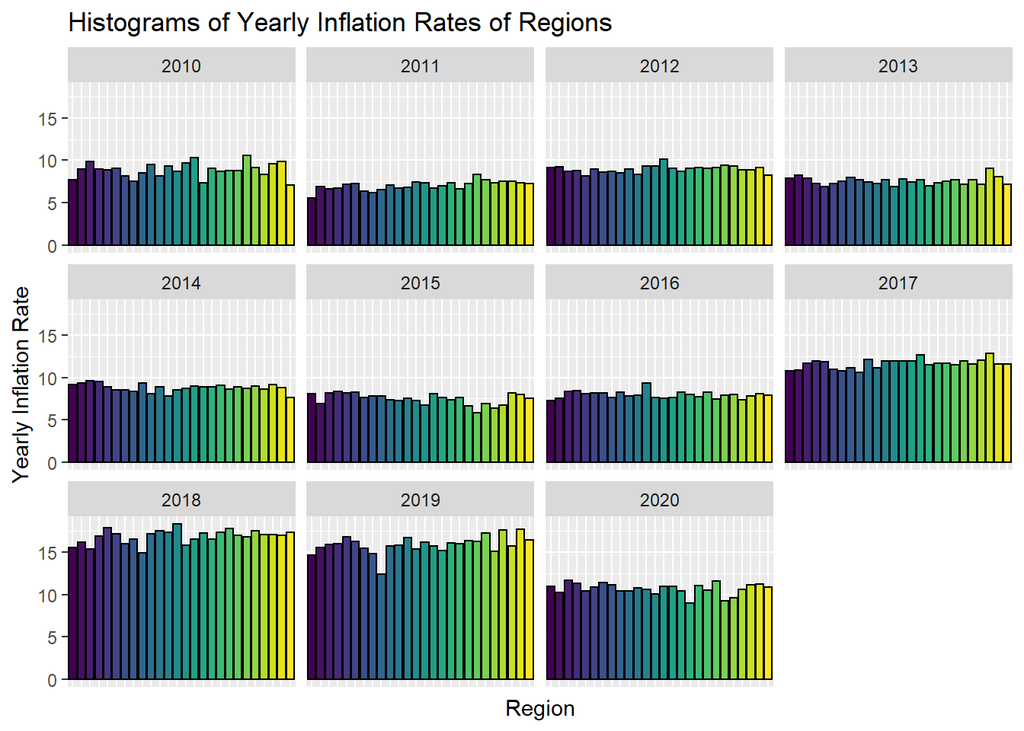

```r
ggplot(inflation,aes(x=factor(Region),y=`Yearly Inflation Rate`))+
  geom_bar(stat="identity", aes(fill=Region),color="black")+
  facet_wrap(~year(Date))+
  theme(legend.position = "none",
        axis.ticks.x = element_blank(),
        axis.text.x = element_blank())+
  scale_fill_viridis_d()+
  labs(x="Region",
      title="Histograms of Yearly Inflation Rates of Regions")
```

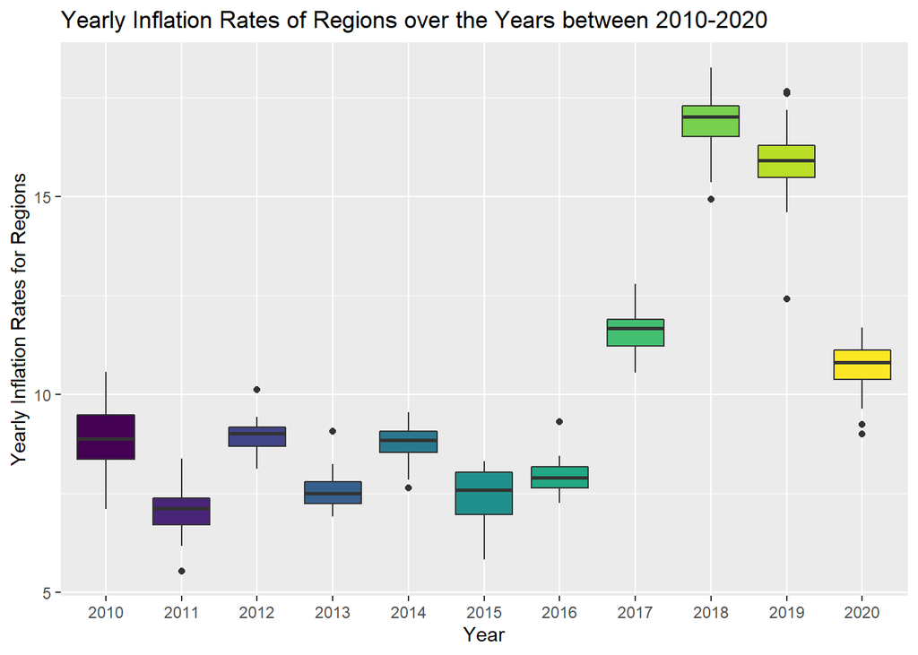

```r
ggplot(inflation,aes(x=factor(year(Date)), y=`Yearly Inflation Rate`))+
  geom_boxplot(aes(fill=factor(year(Date))))+
  theme(legend.position = "none")+
  labs(x="Year",y="Yearly Inflation Rates for Regions",
       title="Yearly Inflation Rates of Regions over the Years between 2010-2020")+
  scale_fill_viridis_d()
```

The shape of histograms is not changing over the years. However, it is also possible to say fluctuations among the regions can appear in certain years such as 2010, 2018,2019, and 2020 while histograms in the years 2013, 2016, and 2017 have flatter shape.

### 3.1.2 Search Volume of the Related Keywords

**Search Volume of “enflasyon” (meaning of “inflation” in Turkish)**

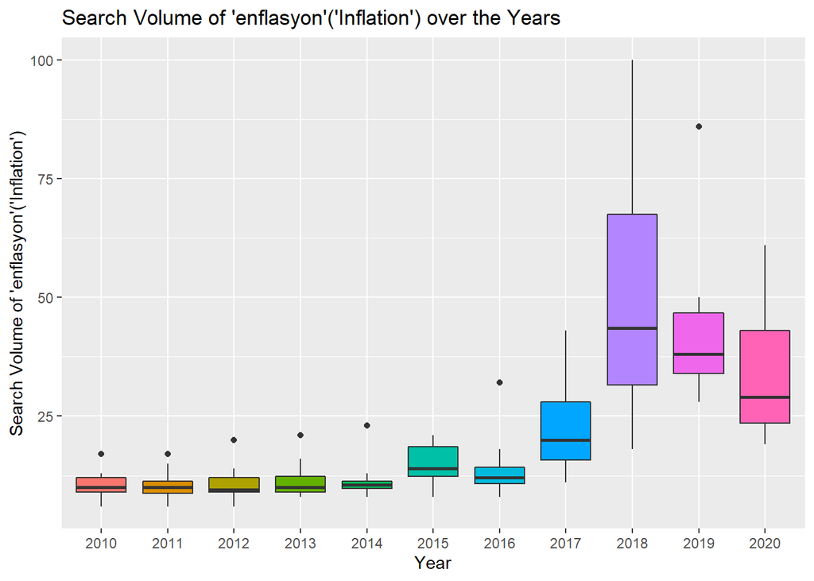

```r
ggplot(search_enflasyon,aes(x=factor(year(Date)), y=Inflation))+
  geom_boxplot(aes(fill=factor(year(Date))))+
  theme(legend.position = "none")+
  labs(x="Year",y="Search Volume of 'enflasyon'('Inflation')",
       title="Search Volume of 'enflasyon'('Inflation') over the Years")
```

**Search Volume of “fiyat artışı” (meaning of “price increase” in Turkish)**

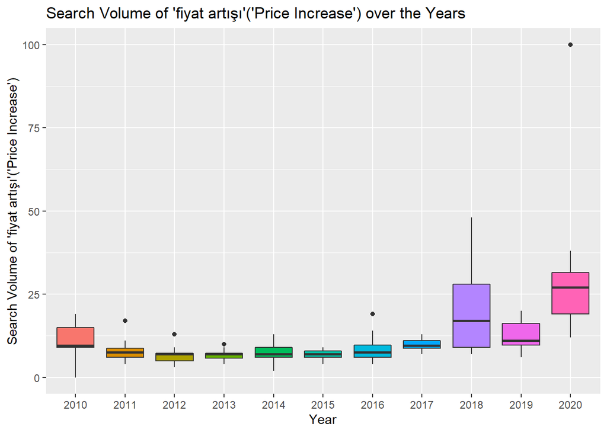

```r
ggplot(search_fiyatartışı,aes(x=factor(year(Date)), y=PriceIncrease))+
  geom_boxplot(aes(fill=factor(year(Date))))+
  theme(legend.position = "none")+
  labs(x="Year",y="Search Volume of 'fiyat artışı'('Price Increase')",
       title="Search Volume of 'fiyat artışı'('Price Increase') over the Years")
```

Similarity between the boxplots becomes clear after the year 2016. Before this year, the volumes are not affected so much by change in the inflation rate, which may result from relatively low (below 10 percent) rates. The higher rates after 2016 might make people more aware and anxious about inflation. The other reason might be change in preference of the people to learn more about current issues.

## 3.2 Unemployment Analysis

### 3.2.1 Monthly Unemployment Rates for each Year

Monthly unemployment rates are plotted for 11 years as histograms below:

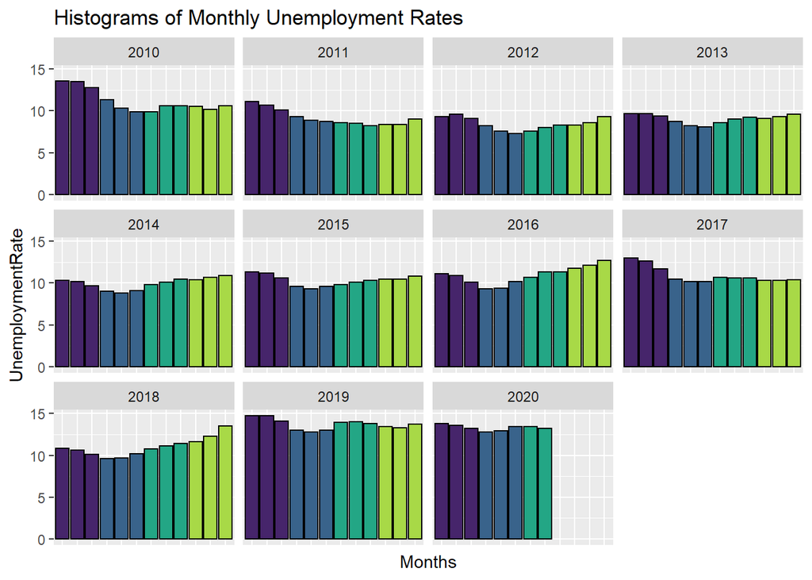

```r
ggplot(unemployment,aes(x=factor(month(Date)),y=UnemploymentRate))+
  geom_bar(stat="identity", aes(fill=month(Date)),color="black")+
  facet_wrap(~year(Date))+
  theme(legend.position = "none",
        axis.ticks.x = element_blank(),
        axis.text.x = element_blank())+
  scale_fill_viridis_b()+
  labs(x="Months",
       title="Histograms of Monthly Unemployment Rates")
```

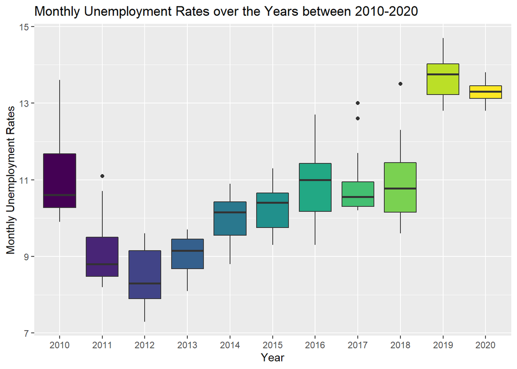

```r
ggplot(unemployment,aes(x=factor(year(Date)), y=UnemploymentRate))+
  geom_boxplot(aes(fill=factor(year(Date))))+
  theme(legend.position = "none")+
  labs(x="Year",y="Monthly Unemployment Rates",
       title="Monthly Unemployment Rates over the Years between 2010-2020")+
  scale_fill_viridis_d()
```

It is hard to say the shape of histograms seems similar over the years but some changes between the periods appear in a similar way. For example, the rates go into a decline after the first three month, then increase again after the sixth month. However, it is not possible to say exactly that there is a pattern for the last three months.

### 3.2.2 Search Volume of the Related Keywords

**Search Volume of “iş ilanı” (meaning of “job post” in Turkish)**

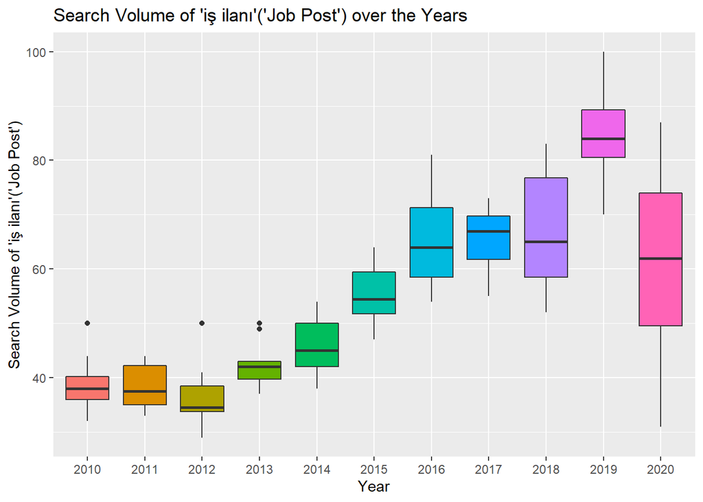

```r
ggplot(search_işilanı,aes(x=factor(year(Date)), y=JobPost))+
  geom_boxplot(aes(fill=factor(year(Date))))+
  theme(legend.position = "none")+
  labs(x="Year",y="Search Volume of 'iş ilanı'('Job Post')",
       title="Search Volume of 'iş ilanı'('Job Post') over the Years")
```

**Search Volume of “işkur” (abbreviation of “Turkish Employment Agency”)**

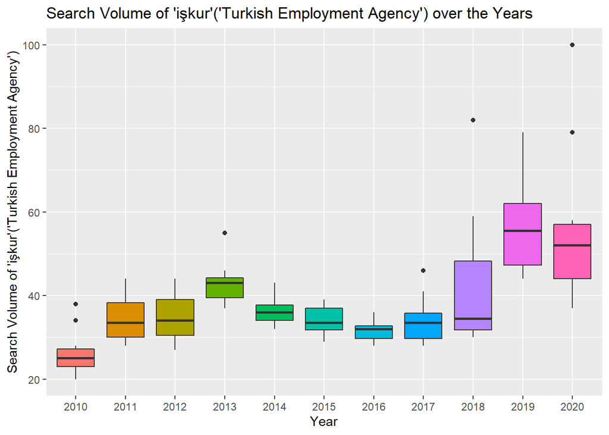

```r
ggplot(search_işkur,aes(x=factor(year(Date)), y=işkur))+
  geom_boxplot(aes(fill=factor(year(Date))))+
  theme(legend.position = "none")+
  labs(x="Year",y="Search Volume of 'işkur'('Turkish Employment Agency')",
      title="Search Volume of 'işkur'('Turkish Employment Agency') over the Years")
```

## 3.3 Car Sales Analysis

### 3.3.1 Monthly Car Sales Amount for each Year

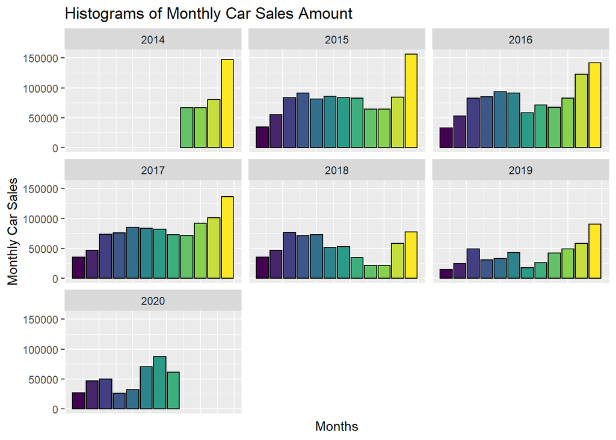

```r
ggplot(car_sales,aes(x=month,y=sales))+
  geom_bar(stat="identity", aes(fill=month),color="black")+
  facet_wrap(~(year))+
  theme(legend.position = "none",
        axis.ticks.x = element_blank(),
        axis.text.x = element_blank())+
  scale_fill_viridis_c()+
  labs(x="Months",
       y="Monthly Car Sales",
       title="Histograms of Monthly Car Sales Amount")
```

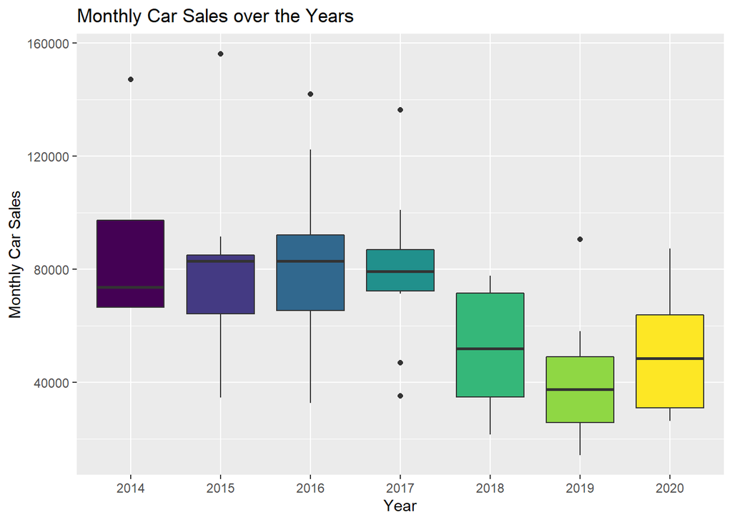

```r
ggplot(car_sales,aes(x=factor(year), y=sales))+
  geom_boxplot(aes(fill=factor(year)))+
  theme(legend.position = "none")+
  labs(x="Year",y="Monthly Car Sales",
       title="Monthly Car Sales over the Years")+
  scale_fill_viridis_d()
```

### 3.3.2 Search Volume of the Related Keyword

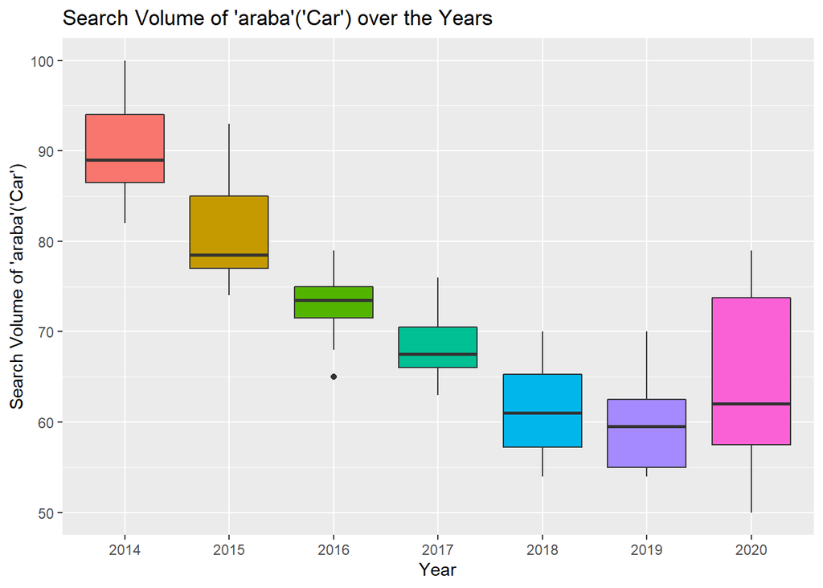

```r
ggplot(search_araba,aes(x=factor(year(Date)), y=araba))+
  geom_boxplot(aes(fill=factor(year(Date))))+
  theme(legend.position = "none")+
  labs(x="Year",y="Search Volume of 'araba'('Car')",
       title="Search Volume of 'araba'('Car') over the Years")
```

The boxplots for the car sales amounts and the search volume of “araba” are quite similar especially after the year 2016. This can imply that the car sales are increasing when people search cars on Google more.